# 6315305_assignment_prediction_model

Andreas Sakapetis

January 18, 2019

**Loading neccessary libraries**

```r
#loading the library "readxl" to be able to use the function read_xlsx().
library(readxl)
#loading the library "formattable" to introduce a table with all the variables.
library(formattable)
#loading the library "ggplot2" to create usefull plots.
library(ggplot2)
#loading the library "GGally" to create usefull plots.
library(GGally)
#loading the library "tidyverse" to perform varius manipulations.
library(tidyverse)
#loading the library "car" to perform VIF.
library(car)
#loading the library "leaps" to perform subset selection.
```

**Import the data from local folder to Rstudio in p.student variable.** __The dataset can be found from kaggle(https://www.kaggle.com/spscientist/students-performance-in-exams/version/1)__

```r
p.student <-
  read.csv("C:\\Users\\Andreas\\Desktop\\Assignment B\\StudentsPerformance.csv",
           header = TRUE)
```

**View the names of the columns in the p.student dataset.**

```r
names(p.student)
```

```
## [1] "gender"                      "race.ethnicity"
## [3] "parental.level.of.education" "lunch"
## [5] "test.preparation.course"     "math.score"
## [7] "reading.score"               "writing.score"
```

**Use the head() function to examine at the first few rows of the p.student dataset.**

```r
head(p.student)
```

```
##   gender race.ethnicity parental.level.of.education        lunch
## 1 female        group B           bachelor's degree     standard
## 2 female        group C                some college     standard
## 3 female        group B             master's degree     standard
## 4   male        group A          associate's degree free/reduced
## 5   male        group C                some college     standard
## 6 female        group B          associate's degree     standard
##   test.preparation.course math.score reading.score writing.score
## 1                    none         72            72            74
## 2               completed         69            90            88
## 3                    none         90            95            93
## 4                    none         47            57            44
## 5                    none         76            78            75
## 6                    none         71            83            78
```

**Use the function tail() to examine the last few rows of the p.student dataset.**

```r
tail(p.student)
```

```
##      gender race.ethnicity parental.level.of.education        lunch
## 995    male        group A                 high school     standard
## 996  female        group E             master's degree     standard
## 997    male        group C                 high school free/reduced
## 998  female        group C                 high school free/reduced
## 999  female        group D                some college     standard
## 1000 female        group D                some college free/reduced
##      test.preparation.course math.score reading.score writing.score
## 995                     none         63            63            62
## 996                completed         88            99            95
## 997                     none         62            55            55
## 998                completed         59            71            65
## 999                completed         68            78            77
## 1000                    none         77            86            86
```

This data set includes scores from three exams and a variety of personal, social, and economic factors that have interaction effects upon them.The dataset consists of 8 variables, with a total of 1000 observations. There are no missing values. Within the dataset exist variables that with the type being either an interger or a factor.

In the study sample, 482/1000 (48.2%) of the students are male 518/1000 (51.8%) are female. The mean math.score is 66.089 points with a standard deviation of 15.16 points (range 0-100 points). The mean of reading.score is 69.169 points with a standard deviation of 14 points (range 0-100 points).

Approximately 31.9% of the sudents are enthnicity group C, 26.2% are group D, 19% are group B, 14% are group E and 8.9% group A. 64.2% of the students did none preparation and 35.8% did a complete preparation.

64.5 % of the students had a standard lunch, while 35.5% of the students had free or reduced lunch. 22.6% of the stundets has parents that acquired some college education, 22.2% associate’s degree education, 19.6% of the students have parents with high scool education and 17.9% some high scool education. 11.8% of the students have parents with a bachelor’s degree and the most scarce of all 5.9% of the students have parents with a master’s degree.

**This function counts missing values**

```r
sapply(p.student, function(x) sum(length(which(is.na(x)))))
```

```
##                      gender              race.ethnicity
##                           0                           0
## parental.level.of.education                       lunch
##                           0                           0
##     test.preparation.course                  math.score
##                           0                           0
##               reading.score               writing.score
##                           0                           0
```

**With sapply function it is possible to examine the type of the variables.**

```r
sapply(p.student,class)
```

```
##                      gender              race.ethnicity
##                    "factor"                    "factor"
## parental.level.of.education                       lunch
##                    "factor"                    "factor"
##     test.preparation.course                  math.score
##                    "factor"                   "integer"
##               reading.score               writing.score
##                   "integer"                   "integer"
```

**With the summary fucntion, the summary statistics for the p.student dataset are obtained.**

```r
summary(p.student)
```

```
##     gender    race.ethnicity     parental.level.of.education
##  female:518   group A: 89    associate's degree:222
##  male  :482   group B:190    bachelor's degree :118
##               group C:319    high school       :196
##               group D:262    master's degree   : 59
##               group E:140    some college      :226
##                              some high school  :179
##           lunch     test.preparation.course   math.score
##  free/reduced:355   completed:358           Min.   :  0.00
##  standard    :645   none     :642           1st Qu.: 57.00
##                                             Median : 66.00
##                                             Mean   : 66.09
##                                             3rd Qu.: 77.00
##                                             Max.   :100.00
##  reading.score    writing.score
##  Min.   : 17.00   Min.   : 10.00
##  1st Qu.: 59.00   1st Qu.: 57.75
##  Median : 70.00   Median : 69.00
##  Mean   : 69.17   Mean   : 68.05
##  3rd Qu.: 79.00   3rd Qu.: 79.00
##  Max.   :100.00   Max.   :100.00
```

**These plots are assisting in identifying trends in the data, using as response** **variable “Math score”.**

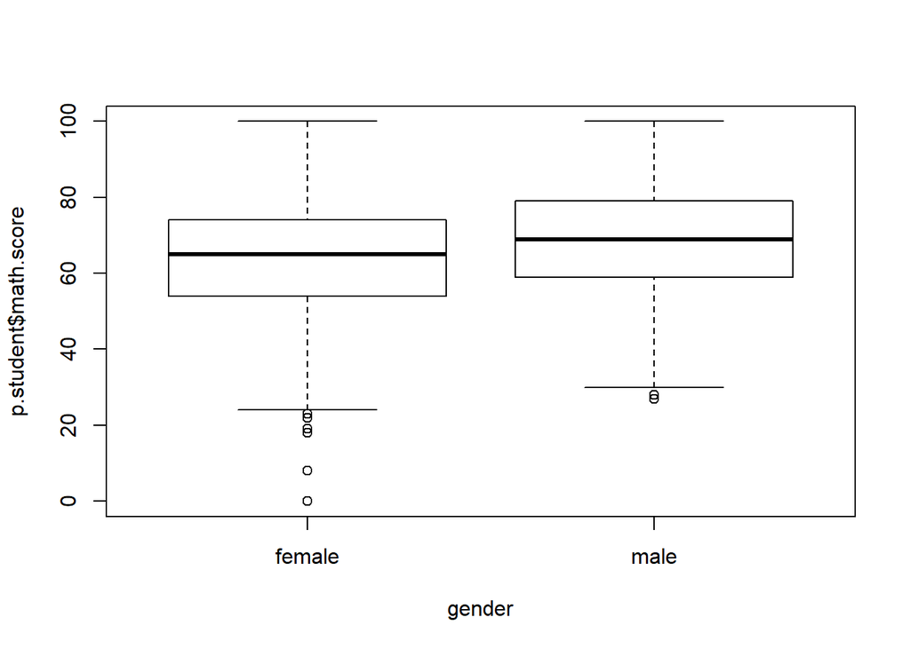

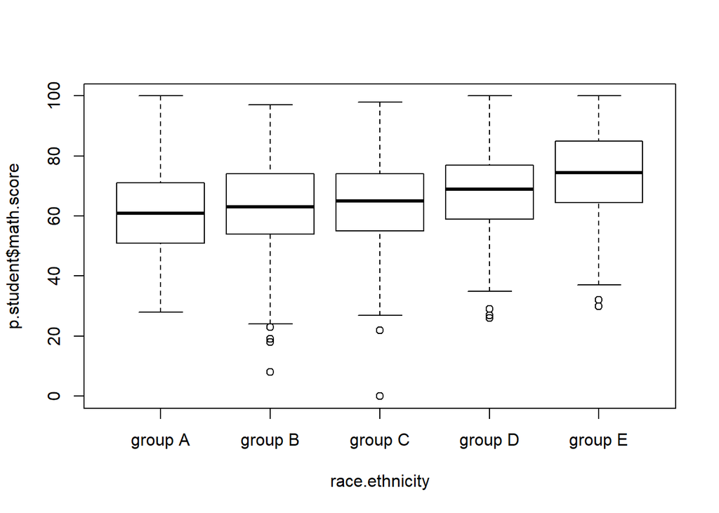

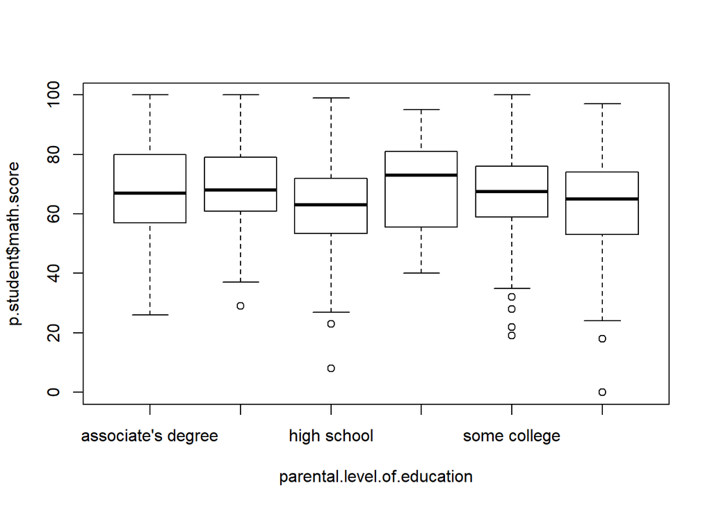

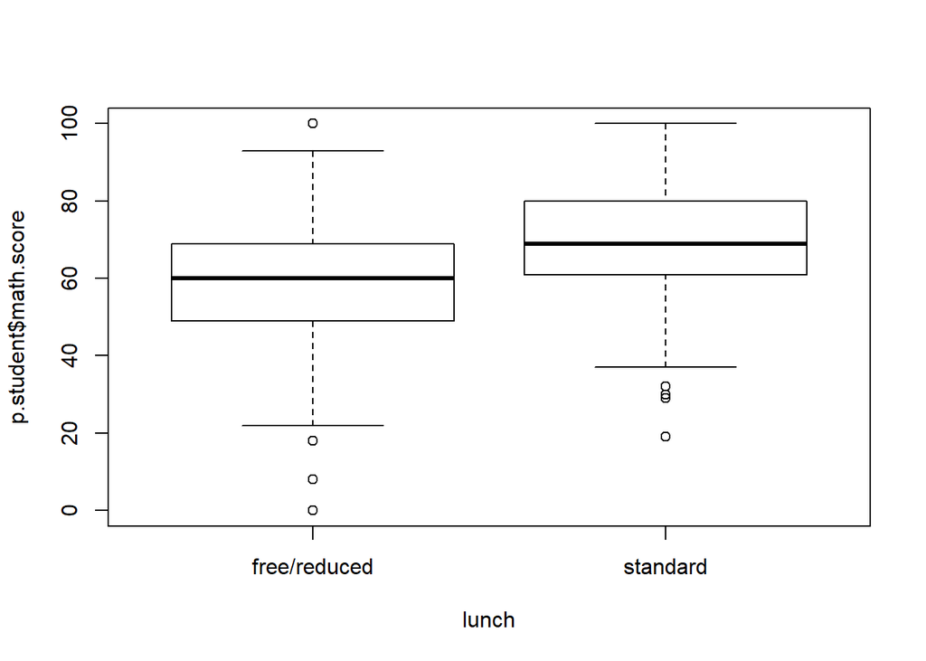

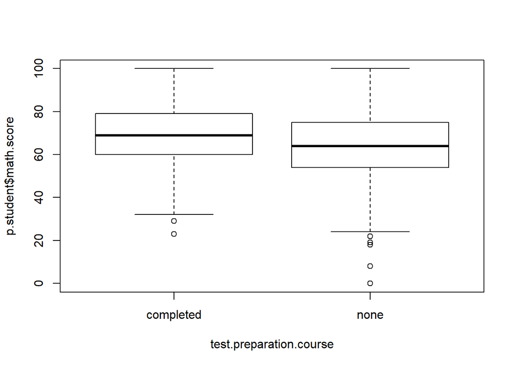

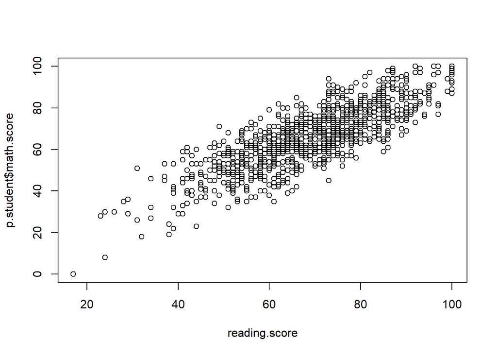

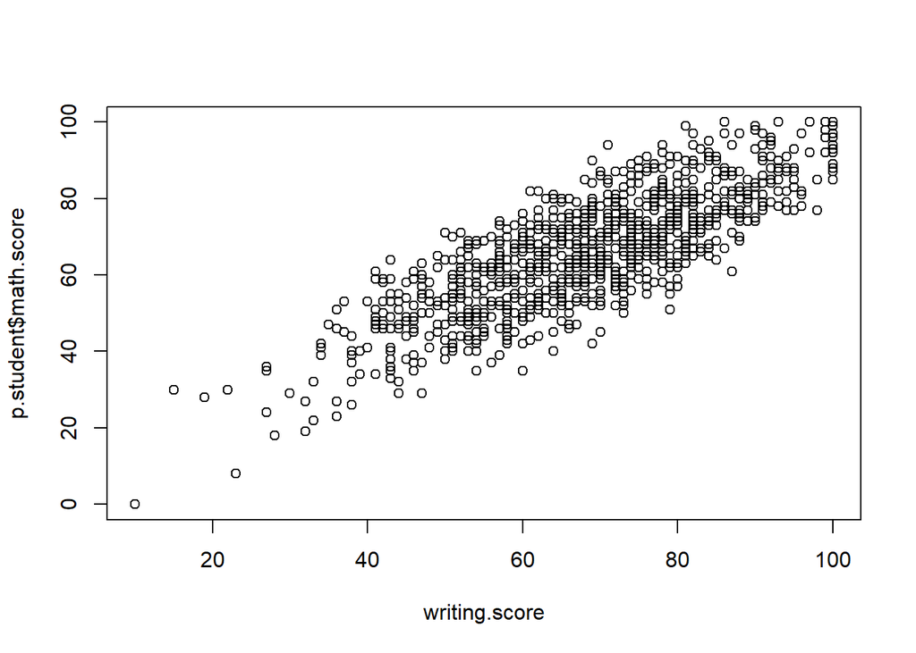

```r
plot(p.student$math.score~.,data=p.student)
```

**These plots are in identifying trends in the data, using as response** **variable “Reading score”.**

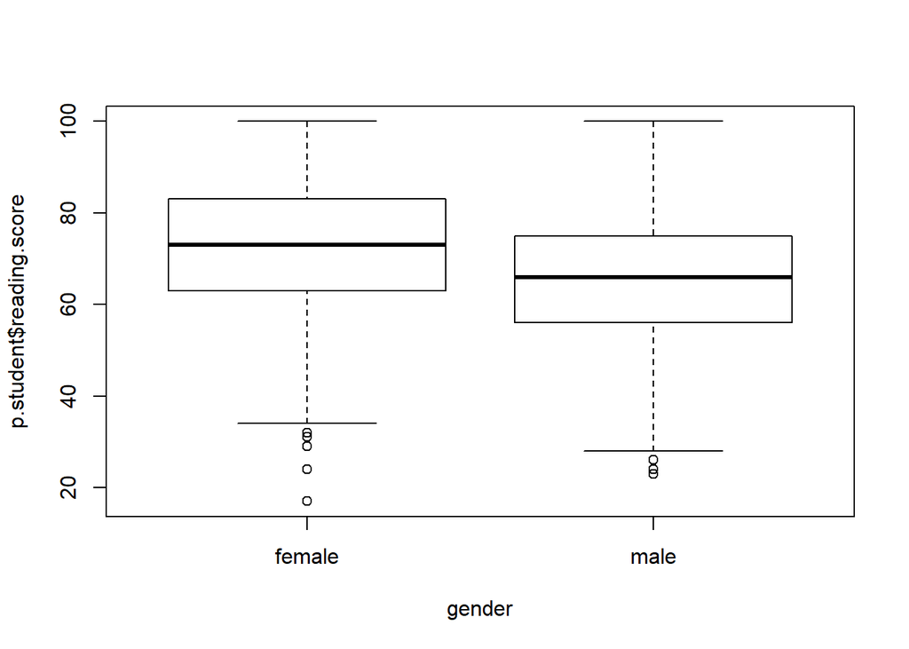

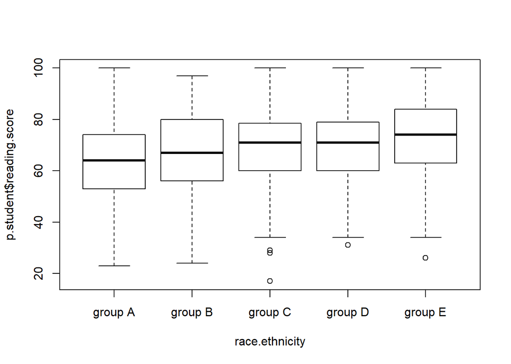

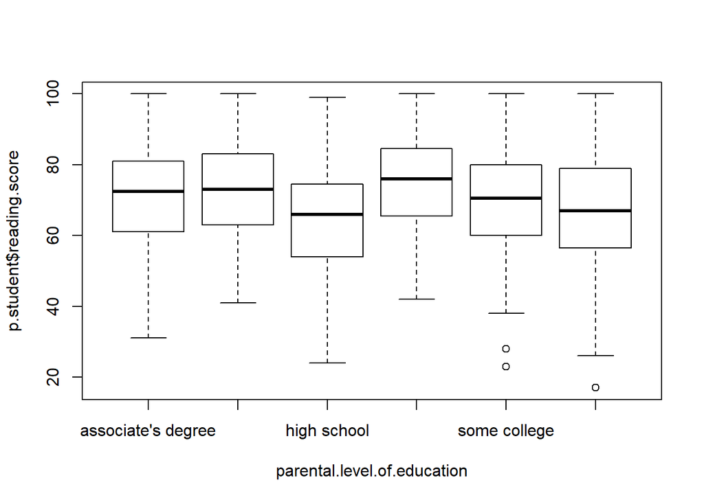

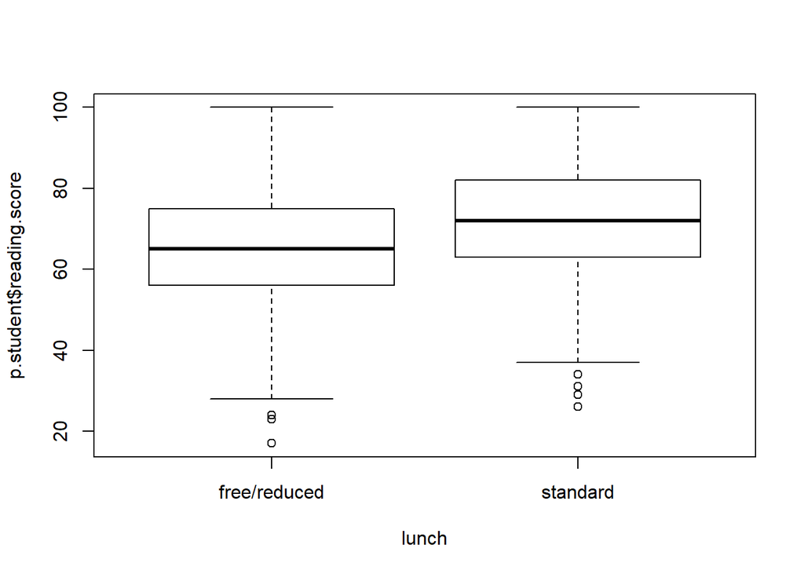

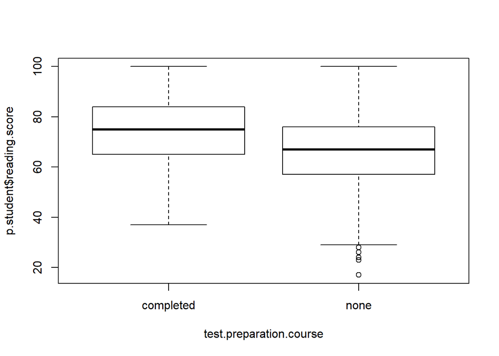

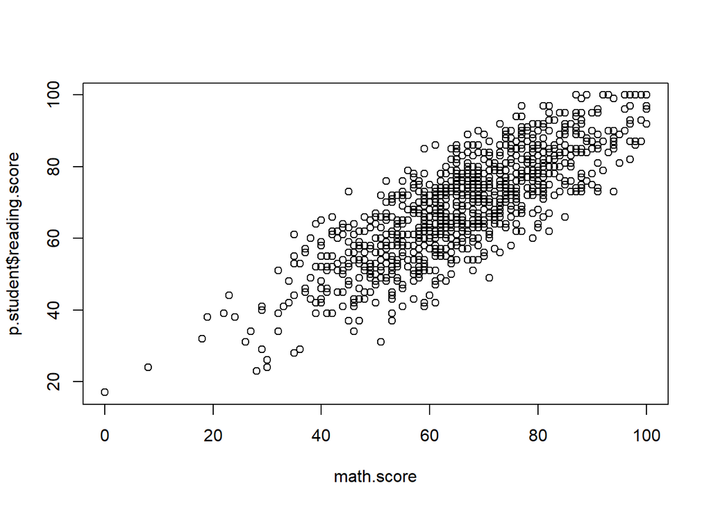

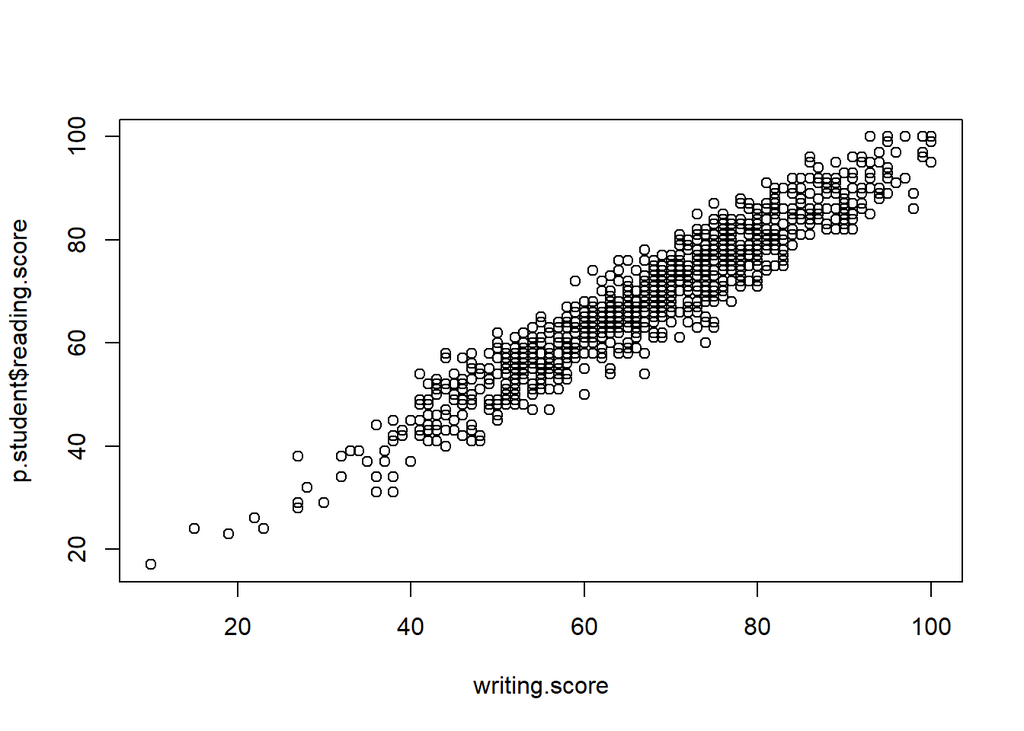

```r
plot(p.student$reading.score~.,data=p.student)
```

**These plots arein identifying trends in the data, using as response** **variable “Writing score”.**

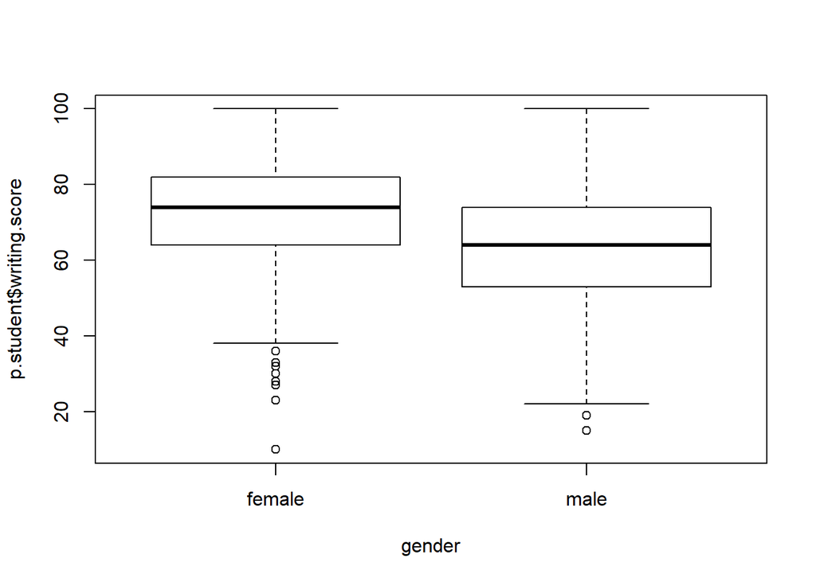

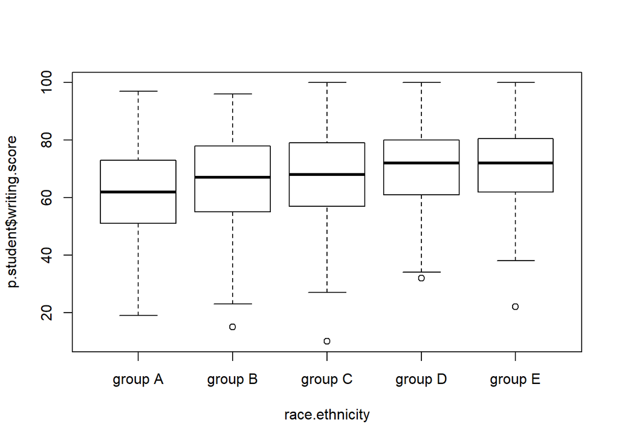

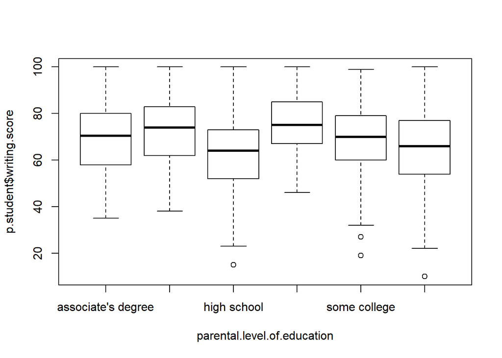

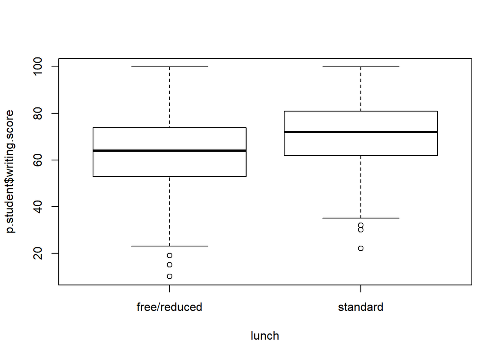

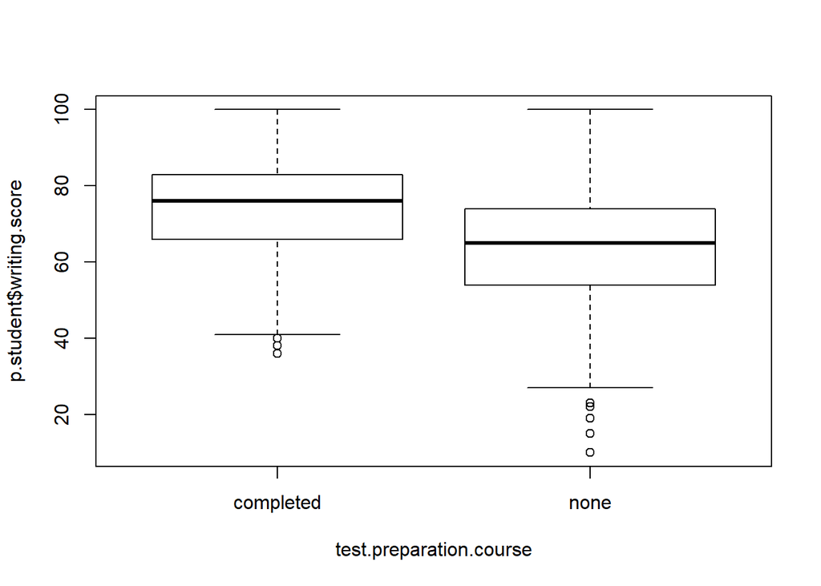

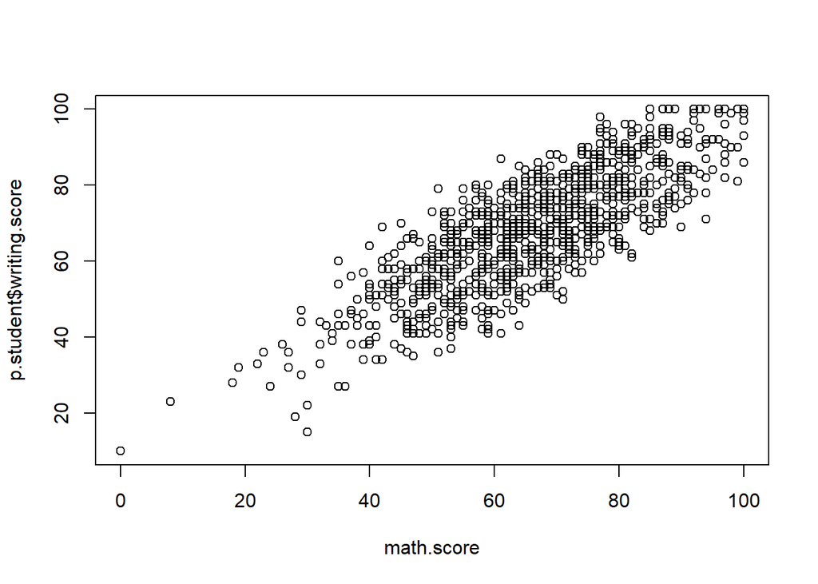

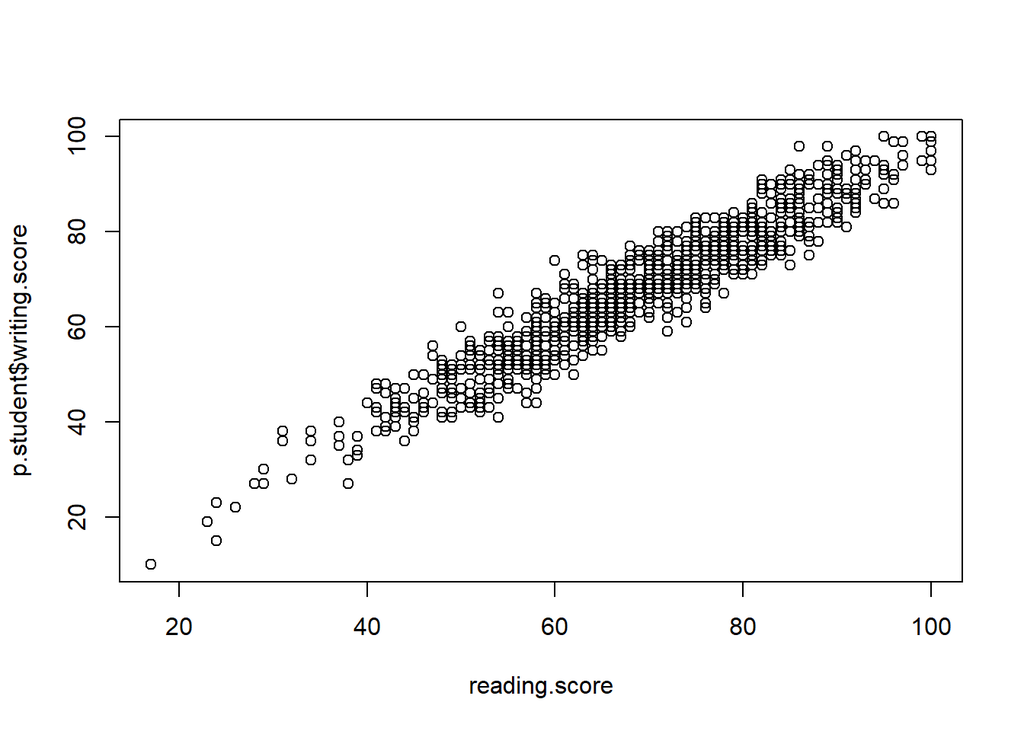

```r
plot(p.student$writing.score~.,data=p.student)
```

**From the scatterplots we can see that the variables reading.score, writing.score** **and math.score appear to have a linear relationship.**

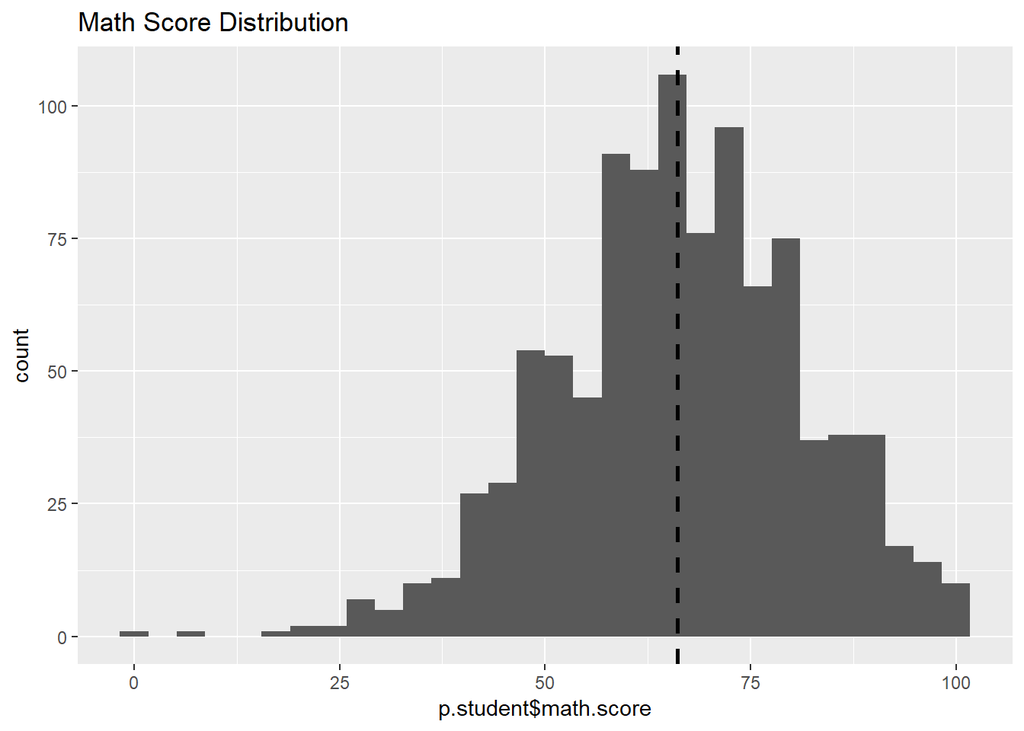

```r
ggplot(p.student)+
geom_histogram(mapping = aes(x = p.student$math.score))+
geom_vline(xintercept=mean(p.student$math.score), lwd=1, linetype=2, color="black")+
  ggtitle("Math Score Distribution")
```

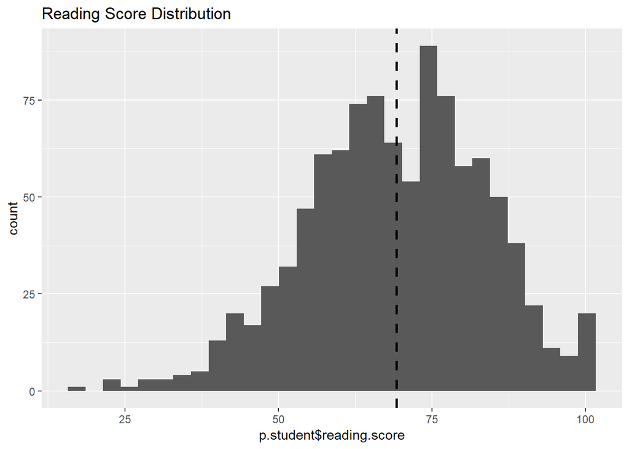

```r
ggplot(p.student)+
geom_histogram(mapping = aes(x = p.student$reading.score))+
geom_vline(xintercept=mean(p.student$reading.score), lwd=1, linetype=2, color="black")+
  ggtitle("Reading Score Distribution")
```

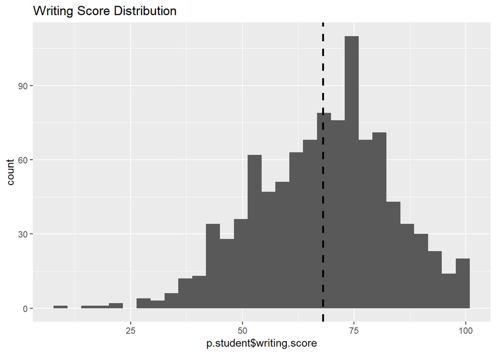

```r
ggplot(p.student)+
geom_histogram(mapping = aes(x = p.student$writing.score))+
geom_vline(xintercept=mean(p.student$writing.score), lwd=1, linetype=2, color="black")+
  ggtitle("Writing Score Distribution")
```

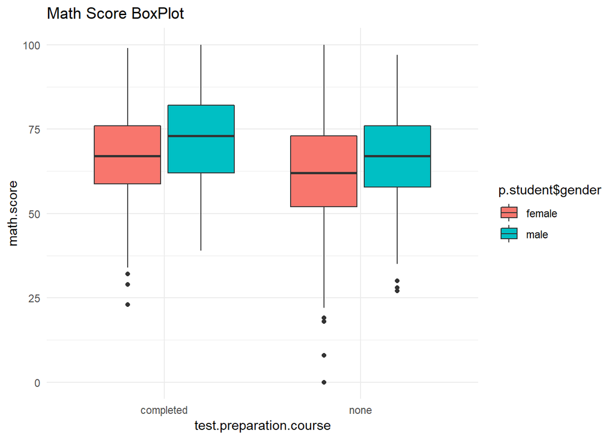

```r
p.student %>%
  ggplot(aes(x = test.preparation.course , y = math.score, fill = p.student$gender)) +
  geom_boxplot() +
  theme_minimal()+
  ggtitle("Math Score BoxPlot")
```

**From the boxplot examination females seem to do less better than males on math.** **From the plot completed preparation is concentrating better scores in math** **than none preperation.** **Outliers are spotted even though from visual examination of the dataset only a** **single value was “0”, which can be interpreated as poor performace.** **The outliers are more spread for females and more concentrated for males.**

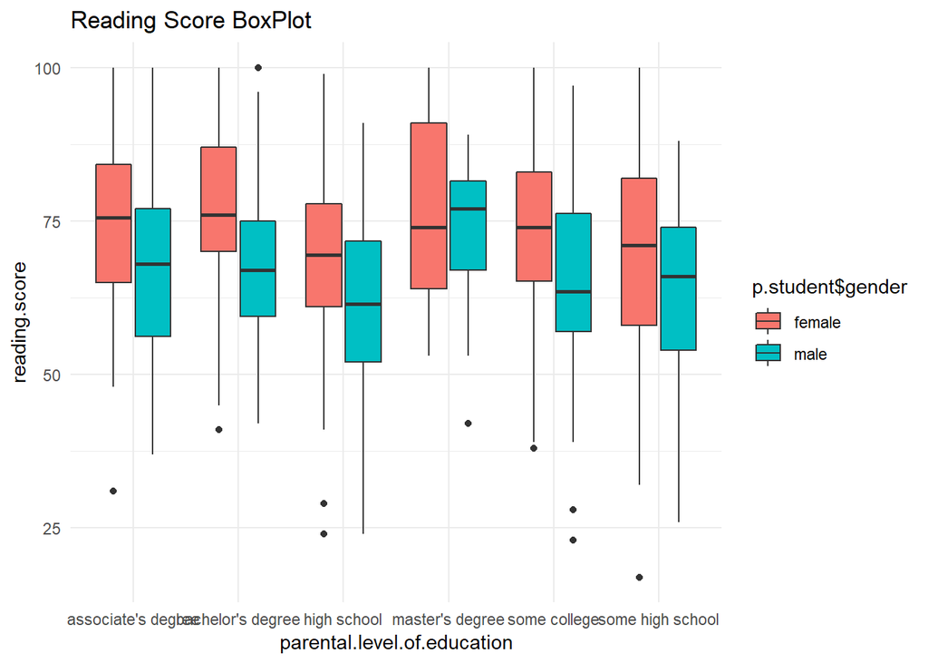

```r
p.student %>%
  ggplot(aes(x = parental.level.of.education , y = reading.score, fill = p.student$gender)) +
  geom_boxplot() +
  theme_minimal()+
  ggtitle("Reading Score BoxPlot")
```

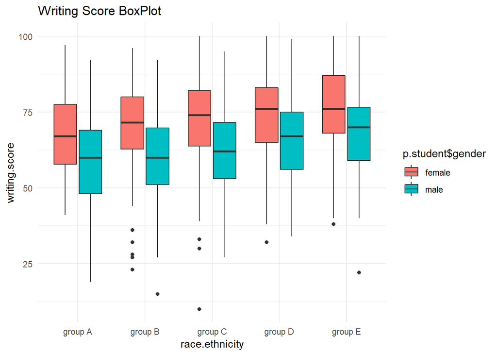

```r
p.student %>%
  ggplot(aes(x = race.ethnicity , y = writing.score, fill = p.student$gender)) +
  geom_boxplot() +
  theme_minimal()+
  ggtitle("Writing Score BoxPlot")
```

**Preparing the dataset to execute the multiple linear regression.**

```r
#Splitting the dataset into a training(75%) and testing set(25%).

#Create a variable "split" that contains 750 times the word train and 250 the
#word test.
split <- c(rep("train", 750), rep("test",  250))

#Divide the dataset based on the words train and test.
p.student <- p.student %>% mutate(split = sample(split))

#Delete the column split
p.student_train <- p.student %>% filter(split == "train")
p.student_train$split <-  NULL

#Delete the column split
p.student_test <- p.student %>% filter(split == "test")
p.student_test$split <-  NULL
```

**Executing the multiple linear regression.**

```r
#The multiple regression model is selected since the input variable is quantitative.
model1 <- lm(formula=p.student_train$math.score ~ . , data=p.student_train)
#Aquire the summary statistics of the multiple linear regression.
summary(model1)
```

```
##
## Call:
## lm(formula = p.student_train$math.score ~ ., data = p.student_train)
##
## Residuals:
##      Min       1Q   Median       3Q      Max
## -17.1793  -3.5098  -0.0184   3.5865  13.3400
##
## Coefficients:
##                                               Estimate Std. Error t value
## (Intercept)                                  -10.82564    1.43605  -7.539
## gendermale                                    12.83615    0.42611  30.124
## race.ethnicitygroup B                         -0.40461    0.79238  -0.511
## race.ethnicitygroup C                         -0.37159    0.74420  -0.499
## race.ethnicitygroup D                         -0.22206    0.76332  -0.291
## race.ethnicitygroup E                          4.53838    0.85028   5.338
## parental.level.of.educationbachelor's degree  -1.27906    0.71002  -1.801
## parental.level.of.educationhigh school         0.31004    0.62624   0.495
## parental.level.of.educationmaster's degree    -2.68346    0.95581  -2.808
## parental.level.of.educationsome college        0.62663    0.58268   1.075
## parental.level.of.educationsome high school    0.61817    0.62904   0.983
## lunchstandard                                  3.17048    0.43410   7.304
## test.preparation.coursenone                    3.38720    0.45385   7.463
## reading.score                                  0.27304    0.04908   5.563
## writing.score                                  0.69265    0.05043  13.736
##                                              Pr(>|t|)
## (Intercept)                                  1.40e-13 ***
## gendermale                                    < 2e-16 ***
## race.ethnicitygroup B                         0.60977
## race.ethnicitygroup C                         0.61770
## race.ethnicitygroup D                         0.77120
## race.ethnicitygroup E                        1.26e-07 ***
## parental.level.of.educationbachelor's degree  0.07204 .
## parental.level.of.educationhigh school        0.62069
## parental.level.of.educationmaster's degree    0.00512 **
## parental.level.of.educationsome college       0.28254
## parental.level.of.educationsome high school   0.32607
## lunchstandard                                7.30e-13 ***
## test.preparation.coursenone                  2.39e-13 ***
## reading.score                                3.71e-08 ***
## writing.score                                 < 2e-16 ***
## ---
## Signif. codes:  0 '***' 0.001 '**' 0.01 '*' 0.05 '.' 0.1 ' ' 1
##
## Residual standard error: 5.349 on 735 degrees of freedom
## Multiple R-squared:  0.8759, Adjusted R-squared:  0.8736
## F-statistic: 370.6 on 14 and 735 DF,  p-value: < 2.2e-16
```

**As it is possible to examine from the summary(), regression coefficient gender** **for male is associated with an increase of 13 points on math.score against females.** **The regression coefficient Race ethnicity E has also significant association** **with an increase of 5 points on math.score against Race ethnicity A.**

**The regression coefficient test.preparation none is associated with an increase** **of 3.4 against completed preparation.**

**The multiple regression estimates $\beta_0$ (the intercept) and** **$\beta_1$,$\beta_2$,$\beta_3$,$\beta_4$,$\beta_5$,$\beta_6$ and $\beta_7$** **in the following equation:**

$$\boldsymbol{y} = \beta_0 + \beta_1\cdot \boldsymbol{x}_1 + \beta_2\cdot \boldsymbol{x}_2+ \beta_3\cdot \boldsymbol{x}_3+\beta_4\cdot \boldsymbol{x}_4+\beta_5\cdot \boldsymbol{x}_5+\beta_6\cdot \boldsymbol{x}_6+ \beta_7\cdot \boldsymbol{x}_7+\boldsymbol{\epsilon}$$

**Through the examination of the multiple regression analysis. The Fstatistic** **p-value is < 2.2e-16. This leads to the conclusion that, there is at least,** **one predictor variable which is significantly related to the outcome variable.**

**The adjusted R-squared indicates that 87% of the variation in math score can be** **explained by the model containing gender,race.ethnicity,parental.level.of.education,** **lunch, test.preparation, reading.score and writing score.**

**To examine which predictor variables are significant, we require estimate of** **regression beta coefficients and the associated t-statitic p-values:**

```r
summary(model1)$coefficient
```

```
##                                                 Estimate Std. Error
## (Intercept)                                  -10.8256373 1.43604537
## gendermale                                    12.8361515 0.42610847
## race.ethnicitygroup B                         -0.4046052 0.79237663
## race.ethnicitygroup C                         -0.3715941 0.74419821
## race.ethnicitygroup D                         -0.2220595 0.76331689
## race.ethnicitygroup E                          4.5383762 0.85027756
## parental.level.of.educationbachelor's degree  -1.2790582 0.71002337
## parental.level.of.educationhigh school         0.3100409 0.62623844
## parental.level.of.educationmaster's degree    -2.6834638 0.95581475
## parental.level.of.educationsome college        0.6266317 0.58268199
## parental.level.of.educationsome high school    0.6181748 0.62904332
## lunchstandard                                  3.1704761 0.43409824
## test.preparation.coursenone                    3.3872025 0.45385217
## reading.score                                  0.2730380 0.04908033
## writing.score                                  0.6926492 0.05042689
##                                                 t value      Pr(>|t|)
## (Intercept)                                  -7.5385064  1.402509e-13
## gendermale                                   30.1241408 1.831845e-130
## race.ethnicitygroup B                        -0.5106223  6.097689e-01
## race.ethnicitygroup C                        -0.4993213  6.177024e-01
## race.ethnicitygroup D                        -0.2909139  7.711993e-01
## race.ethnicitygroup E                         5.3375231  1.256583e-07
## parental.level.of.educationbachelor's degree -1.8014311  7.204467e-02
## parental.level.of.educationhigh school        0.4950844  6.206885e-01
## parental.level.of.educationmaster's degree   -2.8075145  5.124850e-03
## parental.level.of.educationsome college       1.0754266  2.825367e-01
## parental.level.of.educationsome high school   0.9827222  3.260675e-01
## lunchstandard                                 7.3035911  7.304082e-13
## test.preparation.coursenone                   7.4632286  2.391106e-13
## reading.score                                 5.5630850  3.713578e-08
## writing.score                                13.7357105  2.210514e-38
```

**The variables that were selected for the model based on p-value are: gender, lunch,** **test.preparation.course,reading.score and writing.score**

**Before proceding with further investigation, VIF will be examined to find** **whether or not there is colinearity between the predictors.**

```r
vif(model1)
```

```
##                                  GVIF Df GVIF^(1/(2*Df))
## gender                       1.189208  1        1.090508
## race.ethnicity               1.123939  4        1.014712
## parental.level.of.education  1.182265  5        1.016884
## lunch                        1.124775  1        1.060554
## test.preparation.course      1.242028  1        1.114463
## reading.score               12.728553  1        3.567710
## writing.score               14.603959  1        3.821513
```

```r
reduced <-
  lm(formula=p.student_train$math.score ~gender+lunch+test.preparation.course+reading.score+writing.score ,
     data=p.student_train)

summary(reduced)
```

```
##
## Call:
## lm(formula = p.student_train$math.score ~ gender + lunch + test.preparation.course +
##     reading.score + writing.score, data = p.student_train)
##
## Residuals:
##      Min       1Q   Median       3Q      Max
## -17.4974  -3.6210  -0.1298   3.7997  15.7052
##
## Coefficients:
##                              Estimate Std. Error t value Pr(>|t|)
## (Intercept)                 -10.27941    1.25049  -8.220 9.01e-16 ***
## gendermale                   12.86948    0.43944  29.286  < 2e-16 ***
## lunchstandard                 3.38656    0.45174   7.497 1.86e-13 ***
## test.preparation.coursenone   3.08460    0.46697   6.606 7.54e-11 ***
## reading.score                 0.32393    0.04976   6.510 1.38e-10 ***
## writing.score                 0.63906    0.04996  12.791  < 2e-16 ***
## ---
## Signif. codes:  0 '***' 0.001 '**' 0.01 '*' 0.05 '.' 0.1 ' ' 1
##
## Residual standard error: 5.63 on 744 degrees of freedom
## Multiple R-squared:  0.8609, Adjusted R-squared:  0.8599
## F-statistic: 920.7 on 5 and 744 DF,  p-value: < 2.2e-16
```

**There is a reduction in R-squared from 87% to 86%, thus model1 is preferred.**

**With the function prediction(), values for the math.score will be obtained,** **against the observed math.score values.**

```r
y_pred <- predict(model1,newdata = p.student_train)
```

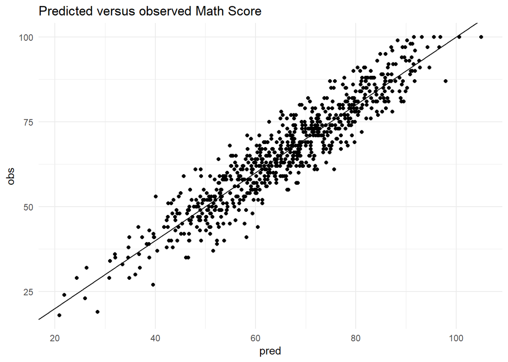

```r
tibble(pred = y_pred,
       obs  = p.student_train$math.score) %>%
  ggplot(aes(x = pred, y = obs)) +
  geom_point() +
  theme_minimal() +
  geom_abline(slope = 1)+
  labs(title = "Predicted versus observed Math Score")
```

**Residuals plot**

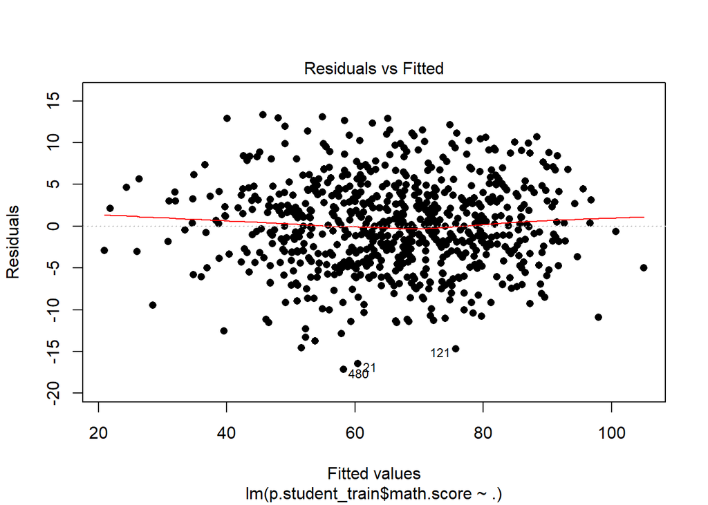

```r
plot(model1, pch=16, which=1)
```

**This residual plot is constructed from the multiple linear regression “model1”.** **The red line is a smooth fit to the residuals.**

**Also, from the histogram on the residuals we can see that they form** **a normal distribution.**

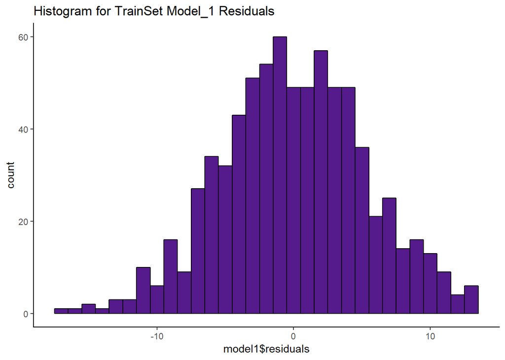

```r
ggplot(data=p.student_train, aes(model1$residuals)) +
    geom_histogram(binwidth = 1, color = "black", fill = "purple4")+
    theme(panel.background = element_rect(fill = "white"),
          axis.line.x=element_line(),
          axis.line.y=element_line()) +
    ggtitle("Histogram for TrainSet Model_1 Residuals")
```

**Performing multiple regression to the test set for cross validation.**

```r
model2 <- lm(formula=math.score ~ . , data=p.student_test)
summary(model2)
```

```
##
## Call:
## lm(formula = math.score ~ ., data = p.student_test)
##
## Residuals:
##      Min       1Q   Median       3Q      Max
## -12.8448  -3.6074   0.2148   3.1040  14.4650
##
## Coefficients:
##                                               Estimate Std. Error t value
## (Intercept)                                  -14.43030    2.53505  -5.692
## gendermale                                    14.41162    0.78703  18.311
## race.ethnicitygroup B                          4.47513    1.42616   3.138
## race.ethnicitygroup C                          1.68201    1.32878   1.266
## race.ethnicitygroup D                          1.07307    1.38527   0.775
## race.ethnicitygroup E                          6.59336    1.49850   4.400
## parental.level.of.educationbachelor's degree  -0.70437    1.24566  -0.565
## parental.level.of.educationhigh school         0.98799    1.03510   0.954
## parental.level.of.educationmaster's degree     0.34596    1.43563   0.241
## parental.level.of.educationsome college        0.05976    1.04566   0.057
## parental.level.of.educationsome high school    0.52132    1.12798   0.462
## lunchstandard                                  3.50770    0.75540   4.643
## test.preparation.coursenone                    3.89073    0.82168   4.735
## reading.score                                  0.24048    0.08357   2.878
## writing.score                                  0.72862    0.08802   8.278
##                                              Pr(>|t|)
## (Intercept)                                  3.72e-08 ***
## gendermale                                    < 2e-16 ***
## race.ethnicitygroup B                         0.00192 **
## race.ethnicitygroup C                         0.20683
## race.ethnicitygroup D                         0.43934
## race.ethnicitygroup E                        1.64e-05 ***
## parental.level.of.educationbachelor's degree  0.57230
## parental.level.of.educationhigh school        0.34082
## parental.level.of.educationmaster's degree    0.80978
## parental.level.of.educationsome college       0.95447
## parental.level.of.educationsome high school   0.64438
## lunchstandard                                5.70e-06 ***
## test.preparation.coursenone                  3.79e-06 ***
## reading.score                                 0.00437 **
## writing.score                                9.47e-15 ***
## ---
## Signif. codes:  0 '***' 0.001 '**' 0.01 '*' 0.05 '.' 0.1 ' ' 1
##
## Residual standard error: 5.324 on 235 degrees of freedom
## Multiple R-squared:  0.8894, Adjusted R-squared:  0.8828
## F-statistic: 134.9 on 14 and 235 DF,  p-value: < 2.2e-16
```